# Project- Differentially expressed genes

Julia Lapucha, Astghik Sarukhanyan, Caroline Forsythe

2024-05-22

How can insights into methylation associated gene regulation and gene expression in endometriosis, aid in the identification of potential biomarkers?

This Markdown will perform a differential expression analysis based on DESEQ2 [Example](https://lashlock.github.io/compbio/R_presentation.html)

Libraries:

```r
pacman::p_load(tidyverse, ggplot2, DESeq2, data.table, vsn, apeglm, biomaRt, ggfortify, BiocManager, ComplexHeatmap, reshape2, EnhancedVolcano)
library("pheatmap")
library("RColorBrewer")
library(EnsDb.Hsapiens.v86)
library(org.Hs.eg.db)
library(ggfortify) #pca
library(plotly)

## setting working directory + load workspace
dir <- "C:/Users/astghik/Documents/Uni/Master/DATA SCIENCE/Project/"
load(paste0(dir, "ANALYSIS/DEGs/rnaseq.RData"))
```

# Count Data

Loading the RNA-seq data:

```r
## set working directory

data <- read.delim(paste0(dir, "DATA/rnaseq/GSE134056_countdata_rnaseq.txt"),
                   header = TRUE)
head(data)
```

|  | N_0026 | N_0035 | N_0036 | N_0039 | N_0042 | N_0045 | N_0046 | N_0054 | N_0055 | N_0057 | N_0058 | N_0060 | W_001 | W_002 | W_004 | W_006 | W_007 | W_008 | W_010 | W_011 | W_012 | W_015 | W_017 | W_018 | W_023 | W_028 | W_030 | W_033 | W_035 | … |
| --- | --- | --- | --- | --- | --- | --- | --- | --- | --- | --- | --- | --- | --- | --- | --- | --- | --- | --- | --- | --- | --- | --- | --- | --- | --- | --- | --- | --- | --- | --- |
| ENSG00000000005 | 2 | 0 | 0 | 0 | 0 | 0 | 2 | 0 | 0 | 0 | 0 | 0 | 0 | 0 | 0 | 0 | 0 | 0 | 1 | 0 | 0 | 1 | 0 | 2 | 0 | 0 | 0 | 1 | 0 | … |
| ENSG00000000419 | 4 | 4 | 5 | 7 | 11 | 14 | 1 | 13 | 8 | 14 | 7 | 10 | 0 | 11 | 8 | 2 | 6 | 3 | 8 | 4 | 8 | 11 | 2 | 10 | 0 | 10 | 8 | 0 | 7 | … |
| ENSG00000000457 | 241 | 153 | 341 | 120 | 322 | 235 | 214 | 257 | 122 | 295 | 271 | 246 | 237 | 276 | 211 | 233 | 208 | 131 | 192 | 240 | 225 | 299 | 119 | 313 | 186 | 259 | 229 | 241 | 232 | … |
| ENSG00000000460 | 241 | 411 | 393 | 381 | 360 | 394 | 292 | 269 | 311 | 357 | 290 | 495 | 340 | 434 | 433 | 424 | 472 | 329 | 416 | 397 | 441 | 409 | 352 | 478 | 206 | 386 | 390 | 439 | 498 | … |
| ENSG00000000938 | 0 | 0 | 0 | 0 | 1 | 0 | 0 | 0 | 0 | 1 | 0 | 0 | 1 | 3 | 0 | 0 | 0 | 0 | 0 | 0 | 0 | 2 | 0 | 0 | 0 | 1 | 1 | 0 | 3 | … |
| ENSG00000000971 | 0 | 0 | 1 | 0 | 0 | 0 | 0 | 2 | 0 | 0 | 0 | 0 | 0 | 0 | 0 | 0 | 0 | 0 | 0 | 0 | 0 | 0 | 0 | 0 | 0 | 0 | 0 | 0 | 0 | … |

```r
dim(data)
```

```
## [1] 58050    38
```

# Sample Information

The data has 38 samples (including 22 control and 16 disease samples):

```r
sample_data <- read.table(paste0(dir, "DATA/rnaseq/sample_info.txt"),
                          header = TRUE, sep = "")
sample_data
```

| ID | Group | Replicate | Name |
| --- | --- | --- | --- |
| GSM3934989 | control | rep1 | N_0026 |
| GSM3934990 | control | rep2 | N_0035 |
| GSM3934991 | control | rep3 | N_0036 |
| GSM3934992 | control | rep4 | N_0039 |
| GSM3934993 | control | rep5 | N_0042 |
| GSM3934994 | control | rep6 | N_0045 |
| GSM3934995 | control | rep7 | N_0046 |
| GSM3934996 | control | rep8 | N_0054 |
| GSM3934997 | control | rep9 | N_0055 |
| GSM3934998 | control | rep10 | N_0057 |

[output cut: 28 more lines]

```r
table(sample_data$Group)
```

```
##
## control disease
##      22      16
```

Order sample_data so that colnames of data matches with order of sample names (otherwise DESEQ won’t run):

```r
sample_data <- sample_data[match(colnames(data), sample_data$Name), ]
all(sample_data$Name == colnames(data))
```

```
## [1] TRUE
```

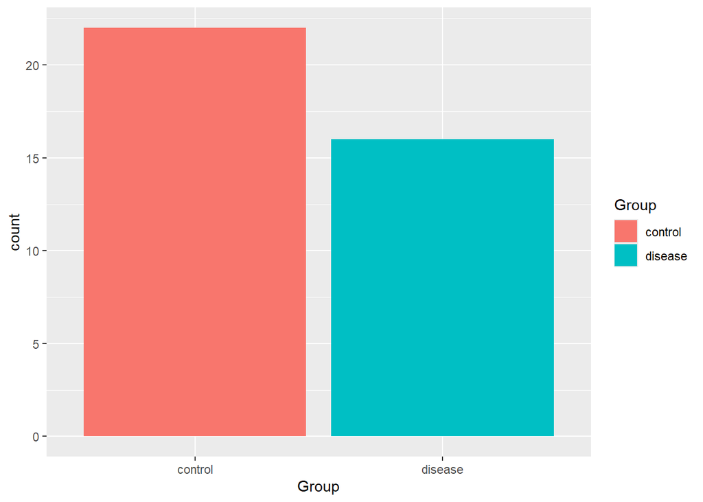

```r
ggplot(sample_data, aes(x = Group, fill = Group)) +
  geom_bar()
```

# DESEQ2

Create a DESeqDataSet object:

```r
dds <- DESeqDataSetFromMatrix(countData = data,
                              colData = sample_data,
                              design = ~ Group)
dim(dds)
```

```
## [1] 58050    38
```

## Pre - Filtering

Remove counts lower than 5:

```r
keep <- rowSums(counts(dds)) >= 5
dds <- dds[keep,]
dim(dds)
```

```
## [1] 29606    38
```

## Define Contrasts or relevel

```r
dds$Group <- factor(dds$Group, levels = c("control","disease"))
dds
```

```
## class: DESeqDataSet
## dim: 29606 38
## metadata(1): version
## assays(1): counts
## rownames(29606): ENSG00000000005 ENSG00000000419 ... ENSG00000283697
##   ENSG00000283698
## rowData names(0):
## colnames(38): N_0026 N_0035 ... W_054 W_058
## colData names(4): ID Group Replicate Name
```

## RESULTS

```r
dds <- DESeq(dds)
res <- results(dds)
res
```

```
## log2 fold change (MLE): Group disease vs control
## Wald test p-value: Group disease vs control
## DataFrame with 29606 rows and 6 columns
##                   baseMean log2FoldChange     lfcSE      stat    pvalue
##                  <numeric>      <numeric> <numeric> <numeric> <numeric>
## ENSG00000000005   0.342277      -0.290072  1.008370 -0.287664  0.773604
## ENSG00000000419   6.306893      -0.397637  0.296978 -1.338941  0.180590
## ENSG00000000457 226.412523      -0.046181  0.130966 -0.352617  0.724376
## ENSG00000000460 363.726914       0.104743  0.107175  0.977304  0.328418
## ENSG00000000938   0.371744       0.779935  1.014370  0.768886  0.441961
## ...                    ...            ...       ...       ...       ...
## ENSG00000283693   1.535009     -0.0585880  0.463305 -0.126457  0.899370
## ENSG00000283694   0.728367     -0.8867325  0.775691 -1.143152  0.252975
## ENSG00000283696   1.179135      0.4296053  0.515677  0.833090  0.404794
## ENSG00000283697   6.684133      0.0426942  0.319729  0.133533  0.893772
## ENSG00000283698  10.695503     -0.3273494  0.421589 -0.776466  0.437474
##                      padj
##                 <numeric>
## ENSG00000000005        NA
## ENSG00000000419        NA
## ENSG00000000457  0.906270
## ENSG00000000460  0.692722
## ENSG00000000938        NA
## ...                   ...
## ENSG00000283693        NA
## ENSG00000283694        NA
## ENSG00000283696        NA
## ENSG00000283697        NA
## ENSG00000283698  0.764435
```

# DATA EXPLORATION

## MA PLOT

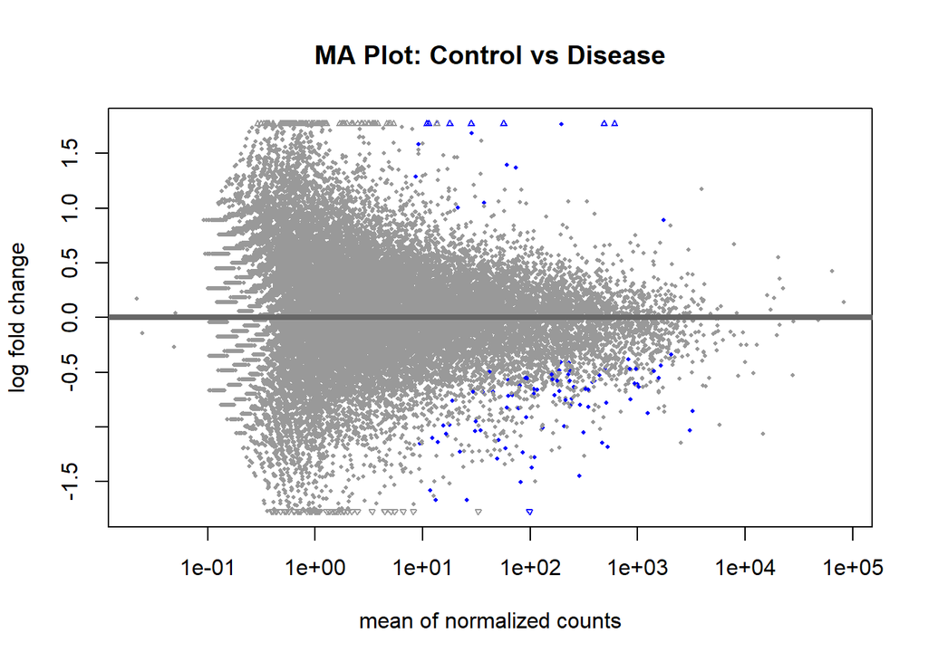

```r
plotMA(res, alpha = 0.05, main = "MA Plot: Control vs Disease")
```

Interpretation: A horizontal spread of points around the zero line indicates a balanced comparison, while a skewed spread might suggest biases

High abs(LFC) for a lot of low count data.

## Shrinkage

Shrinkage might be useful (shrunken fold changes are useful for ranking genes by effect size and for visualization). > The shrunken log fold changes are useful for ranking and visualization, without the need for arbitrary filters on low count genes.

[DESEQ2-Tutorial](https://bioconductor.org/packages/devel/bioc/vignettes/DESeq2/inst/doc/DESeq2.html)

```r
resNorm <- lfcShrink(dds, coef=2, type="normal")
resLFC <- lfcShrink(dds, coef=2, type="apeglm")
resAsh <- lfcShrink(dds, coef=2, type="ashr")
```

MA Plots after shrinkage:

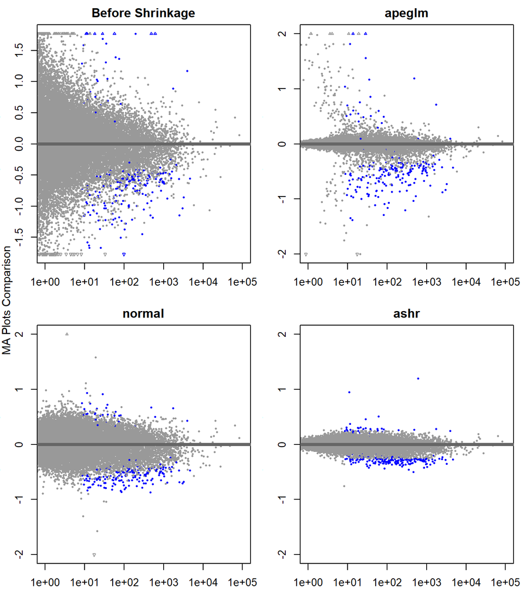

```r
par(mfrow=c(2,2), mar=c(3,3,2,1))
xlim <- c(1, 1e5); ylim <- c(-2, 2)
plotMA(res, xlim=xlim,  main="Before Shrinkage")
plotMA(resLFC, xlim=xlim, ylim=ylim, main="apeglm") # load library(apeglm) to work
plotMA(resNorm, xlim=xlim, ylim=ylim, main="normal")
plotMA(resAsh, xlim=xlim, ylim=ylim, main="ashr")
mtext("MA Plots Comparison", outer = TRUE, cex = 0.9, line = -1, side = 2)
```

We’ll prefer apeglm and use resLFC for visualization purposes of DEGs in plots like Heatmaps, VolcanoPlots etc.

[When use shrinken values?](https://hbctraining.github.io/DGE_workshop/lessons/05_DGE_DESeq2_analysis2.html)

> For example, if you wanted to subset your significant genes based on fold change for further evaluation, you may want to use shruken values.

## VST

In RNA-Seq data variance grows with the mean.

“This function calculates a variance stabilizing transformation (VST) from the fitted dispersion-mean relation(s) and then transforms the count data (normalized by division by the size factors or normalization factors), yielding a matrix of values which are now approximately homoskedastic (having constant variance along the range of mean values). The transformation also normalizes with respect to library size. The rlog is less sensitive to size factors, which can be an issue when size factors vary widely. These transformations are useful when checking for outliers or as input for machine learning techniques such as clustering or linear discriminant analysis.” [source](https://rdrr.io/bioc/DESeq2/man/varianceStabilizingTransformation.html)

Apply Variance stabilizing transformation (useful for clustering or when used as input in machine learning algoritgmis, data should be homoskedastic):

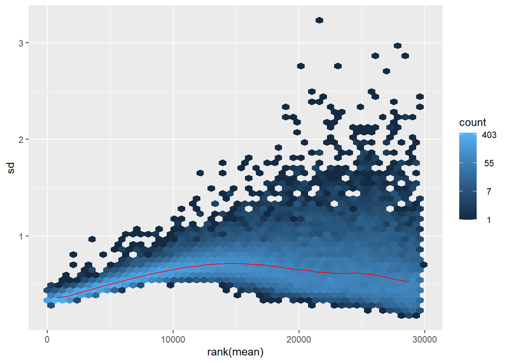

```r
vsd <- vst(dds, blind=FALSE)
meanSdPlot(assay(vsd))
```

```r
## save vsd as rds object to later use input for further analysis like WGCNA
## we later excluded the WGCNA
saveRDS(object = vsd, file = paste0(dir, "ANALYSIS/DEGs/Output/vsd.rds"))
```

## PCA

> “PCA can be used to visualize variation between expression analysis samples. This method is especially useful for quality control, for example in identifying problems with your experimental design, mislabeled samples, or other problems.” [PCA](https://assets.geneious.com/manual/2020.2/static/GeneiousManualsu109.html)

Use vst transformed data for pca as recommended in Deseq2 Tutorial.

PCA Plot without differentiating between replicates:

```r
pcadata <- plotPCA(vsd, intgroup= c("Group", "Replicate"), returnData = T) #using the DESEQ2 plotPCA
pcadata
```

|  | PC1 | PC2 | group | Group | Replicate | name |
| --- | --- | --- | --- | --- | --- | --- |
| N_0026 | -29.220161 | -0.3057388 | control:rep1 | control | rep1 | N_0026 |
| N_0035 | 22.256864 | -13.8473797 | control:rep2 | control | rep2 | N_0035 |
| N_0036 | -22.192561 | 11.6147297 | control:rep3 | control | rep3 | N_0036 |
| N_0039 | 25.298190 | -10.4615659 | control:rep4 | control | rep4 | N_0039 |
| N_0042 | -21.375096 | 6.2236829 | control:rep5 | control | rep5 | N_0042 |
| N_0045 | -25.000866 | 9.0868019 | control:rep6 | control | rep6 | N_0045 |
| N_0046 | 8.298205 | 27.2990694 | control:rep7 | control | rep7 | N_0046 |
| N_0054 | -10.134046 | 15.7159026 | control:rep8 | control | rep8 | N_0054 |
| N_0055 | 25.696245 | -3.3958920 | control:rep9 | control | rep9 | N_0055 |
| N_0057 | -29.435087 | 4.5942376 | control:rep10 | control | rep10 | N_0057 |

[output cut: 28 more lines]

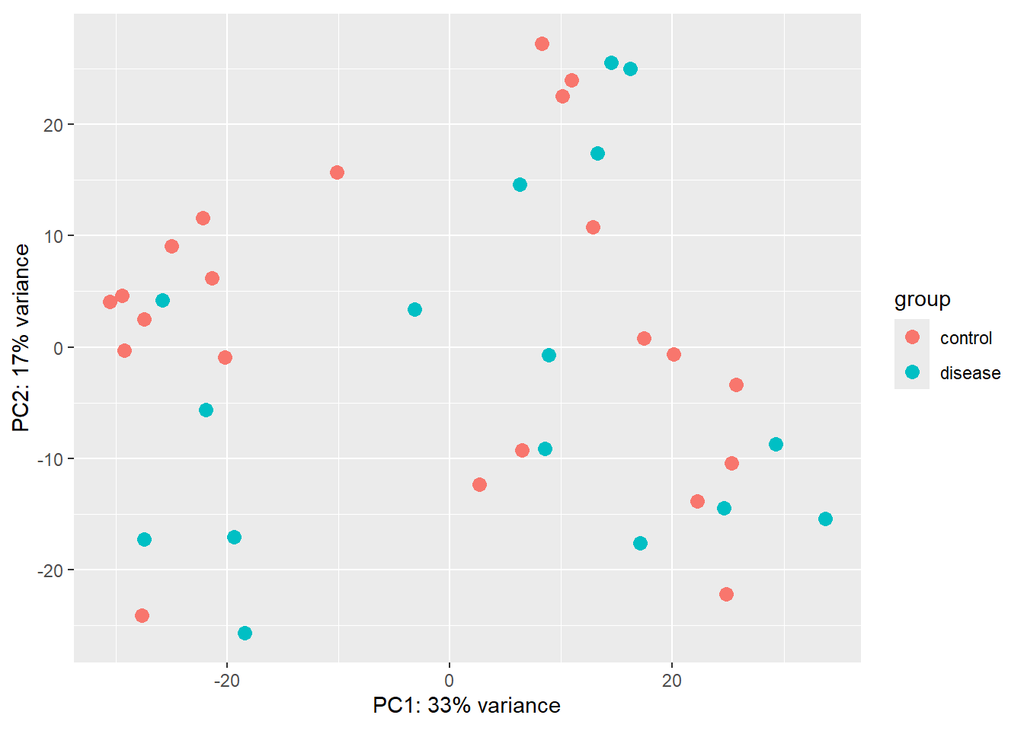

```r
plotPCA(vsd, intgroup="Group")
```

Using ggplot2:

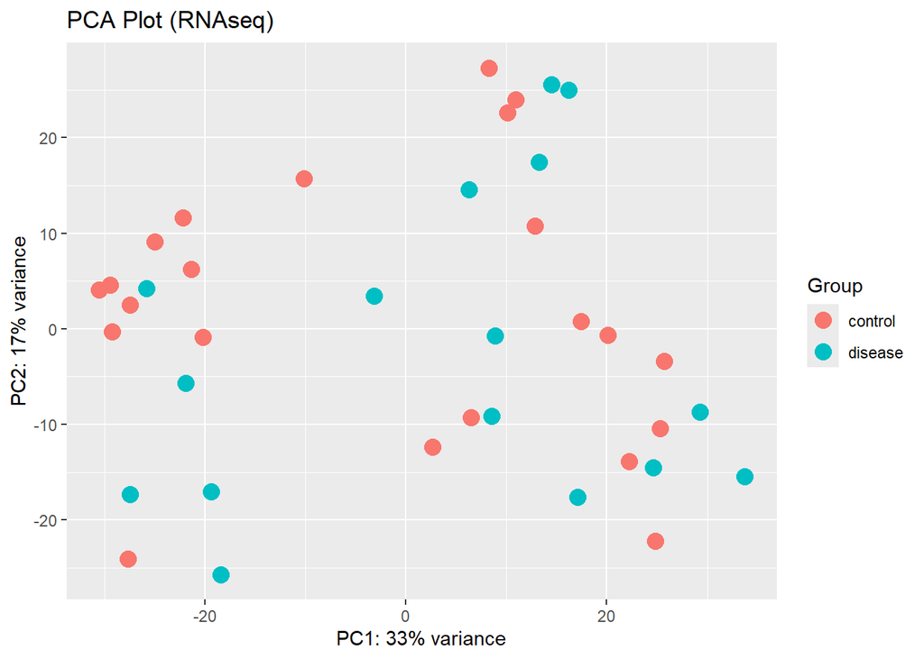

```r
percentVar <- round(100 * attr(pcadata, "percentVar"))

pca_plot <-ggplot(pcadata, aes(PC1, PC2, color = Group)) +
  geom_point(size = 4) +
  ggtitle("PCA Plot (RNAseq)") +
  # theme_bw() +
  theme_gray() +
  xlab(paste0("PC1: ",percentVar[1],"% variance")) +
  ylab(paste0("PC2: ",percentVar[2],"% variance"))
pca_plot
```

PCA Plot additionally differentiating between replicates:

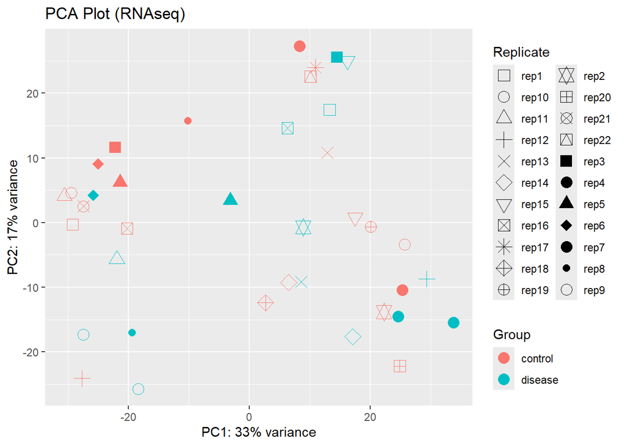

```r
# vector of shapes for Replicate - we have 22 replicates
rep_shapes <- c(0, 1, 2, 3, 4, 5, 6, 7, 8, 9, 10, 11, 12, 13, 14, 15, 16, 17, 18, 19, 20, 21)

pca_plot_shape <- ggplot(pcadata, aes(x = PC1, y = PC2, color = Group,
                    shape = as.factor(Replicate))) +
  geom_point(size = 4) +
  labs(title = "PCA Plot (RNAseq)", color = "Group",
       shape = "Replicate") +
  scale_shape_manual(values = rep_shapes) +  # Manually specify shapes
  xlab(paste0("PC1: ",percentVar[1],"% variance")) +
  ylab(paste0("PC2: ",percentVar[2],"% variance"))+
  theme_gray()

pca_plot_shape
```

# ANNOTATION

FROM ENSEMBL TO GENE SYMBOLS:

Using Genome wide annotation for Human: [org.Hs.eg.db](https://bioconductor.org/packages/release/data/annotation/html/org.Hs.eg.db.html)

How to annotate data: [INFO](https://www.bioconductor.org/help/course-materials/2015/UseBioconductorFeb2015/A01.5_Annotation.html) [OR](https://qfab-bioinformatics.github.io/workshops-RNAseq-analysis-with-R/gene-annotation.html)

Using org.Hs.eg.db to find gene SYMBOLS, unfortunately some are missing, so we tried to use biomart to see, whether it works better and more gene symbols can be identified.

## org.Hs.eg.db

```r
annot<-mapIds(org.Hs.eg.db, keys = rownames(resLFC),
                         keytype = "ENSEMBL", column = "SYMBOL")

sum(is.na(annot))
```

```
## [1] 9193
```

## Biomart

Annotation using biomart:

```r
mart<- useEnsembl(biomart="ensembl",
                  dataset="hsapiens_gene_ensembl",
                  GRCh=38)
# mart %>% listFilters() %>% View()
# mart %>% listAttributes() %>% View()


annot <- getBM(filters= "ensembl_gene_id",
                   attributes=c("ensembl_gene_id","external_gene_name","description"),
                   values= rownames(resLFC),
                   mart= mart)
```

Still gene symbols missing, but less:

```r
annot %>% dplyr::filter(external_gene_name == "") %>% nrow
```

```
## [1] 6441
```

> Before Visualisation of significant DEGs we have to look into the GENE Symbols manually using the ENSEMBL DATA BASE

[ENSEMBL](https://www.ensembl.org/index.html)

But first let’s merge annotation information and shrinked results:

```r
resShrink <- resLFC %>% as.data.frame() %>%
  rownames_to_column(var = "ensembl_gene_id")

resShrink<- merge(resShrink, annot, by="ensembl_gene_id")
head(resShrink)
```

|  | ensembl_gene_id | baseMean | log2FoldChange | lfcSE | pvalue | padj | external_gene_name | description |
| --- | --- | --- | --- | --- | --- | --- | --- | --- |
| 1 | ENSG00000000005 | 0.3422765 | -0.004134367 | 0.11162228 | 0.7736040 | NA | TNMD | tenomodulin [Source:HGNC Symbol;Acc:HGNC:17757] |
| 2 | ENSG00000000419 | 6.3068929 | -0.054895714 | 0.12199224 | 0.1805898 | NA | DPM1 | dolichyl-phosphate mannosyltransferase subunit 1, catalytic [Source:HGNC Symbol;Acc:HGNC:3005] |
| 3 | ENSG00000000457 | 226.4125230 | -0.018792249 | 0.08622934 | 0.7243758 | 0.9062704 | SCYL3 | SCY1 like pseudokinase 3 [Source:HGNC Symbol;Acc:HGNC:19285] |
| 4 | ENSG00000000460 | 363.7269142 | 0.058017977 | 0.08421447 | 0.3284185 | 0.6927217 | FIRRM | FIGNL1 interacting regulator of recombination and mitosis [Source:HGNC Symbol;Acc:HGNC:25565] |
| 5 | ENSG00000000938 | 0.3717438 | 0.011275551 | 0.11232097 | 0.4419608 | NA | FGR | FGR proto-oncogene, Src family tyrosine kinase [Source:HGNC Symbol;Acc:HGNC:3697] |
| 6 | ENSG00000000971 | 0.1305190 | -0.004963822 | 0.11220472 | 0.7676123 | NA | CFH | complement factor H [Source:HGNC Symbol;Acc:HGNC:4883] |

> Results now contain annotated information

# DEGS

Differentially expressed genes:

After exploring our data and obtaining initial insights, we now aim to identify significant genes. By setting specific thresholds, we can extract these from our results. We’ll consider genes as significant if they have a log2 fold change (LFC) greater than 0.5 and a p-value less than alpha.

Genes with a positive log2 fold change will be classified as upregulated, while those with a negative log2 fold change will be classified as downregulated (so we filtered only based on padj initially).

```r
lfc_cutoff = 0.5
alpha = 0.05
sig_005 <- resShrink %>% as.data.frame() %>%
  mutate(gene_exp = ifelse(log2FoldChange < 0, "down", "up")) %>%
  dplyr::filter(padj < alpha) #  & abs(log2FoldChange < 0.5)

sig_005
```

| ensembl_gene_id | baseMean | log2FoldChange | lfcSE | pvalue | padj | external_gene_name | description | gene_exp |
| --- | --- | --- | --- | --- | --- | --- | --- | --- |
| ENSG00000040531 | 245.664718 | -0.62241629 | 0.2219716 | 2.130697e-04 | 0.029228965 | CTNS | cystinosin, lysosomal cystine transporter [Source:HGNC Symbol;Acc:HGNC:2518] | down |
| ENSG00000066230 | 313.395216 | -0.84926326 | 0.3408092 | 3.836496e-04 | 0.038828178 | SLC9A3 | solute carrier family 9 member A3 [Source:HGNC Symbol;Acc:HGNC:11073] | down |
| ENSG00000077157 | 196.192939 | 0.04446617 | 0.1214844 | 1.418887e-04 | 0.023234570 | PPP1R12B | protein phosphatase 1 regulatory subunit 12B [Source:HGNC Symbol;Acc:HGNC:7619] | up |
| ENSG00000092098 | 188.054765 | -0.56510545 | 0.1997210 | 1.959776e-04 | 0.028274834 | RNF31 | ring finger protein 31 [Source:HGNC Symbol;Acc:HGNC:16031] | down |
| ENSG00000099901 | 193.753827 | -0.34417506 | 0.1255530 | 4.597645e-04 | 0.041868848 | RANBP1 | RAN binding protein 1 [Source:HGNC Symbol;Acc:HGNC:9847] | down |
| ENSG00000100242 | 494.682822 | -0.39287755 | 0.1455830 | 4.371348e-04 | 0.041868848 | SUN2 | Sad1 and UNC84 domain containing 2 [Source:HGNC Symbol;Acc:HGNC:14210] | down |
| ENSG00000102904 | 379.571350 | -0.51118383 | 0.1568396 | 5.652865e-05 | 0.018722336 | TSNAXIP1 | translin associated factor X interacting protein 1 [Source:HGNC Symbol;Acc:HGNC:18586] | down |
| ENSG00000103260 | 13.773962 | -0.96789031 | 0.3232441 | 9.950799e-05 | 0.021130706 | METRN | meteorin, glial cell differentiation regulator [Source:HGNC Symbol;Acc:HGNC:14151] | down |
| ENSG00000104872 | 45.419838 | -0.56689739 | 0.2006401 | 2.114095e-04 | 0.029228965 | PIH1D1 | PIH1 domain containing 1 [Source:HGNC Symbol;Acc:HGNC:26075] | down |
| ENSG00000104886 | 108.553638 | -0.56393854 | 0.2242281 | 4.669816e-04 | 0.042018297 | PLEKHJ1 | pleckstrin homology domain containing J1 [Source:HGNC Symbol;Acc:HGNC:18211] | down |

[output cut: 90 more lines]

How many significant DEGs (alpha < 0.05)?

```r
nrow(sig_005)
```

```
## [1] 100
```

```r
## How many not annotated?
sig_005 %>% dplyr::filter(external_gene_name== "") %>% nrow()
```

```
## [1] 28
```

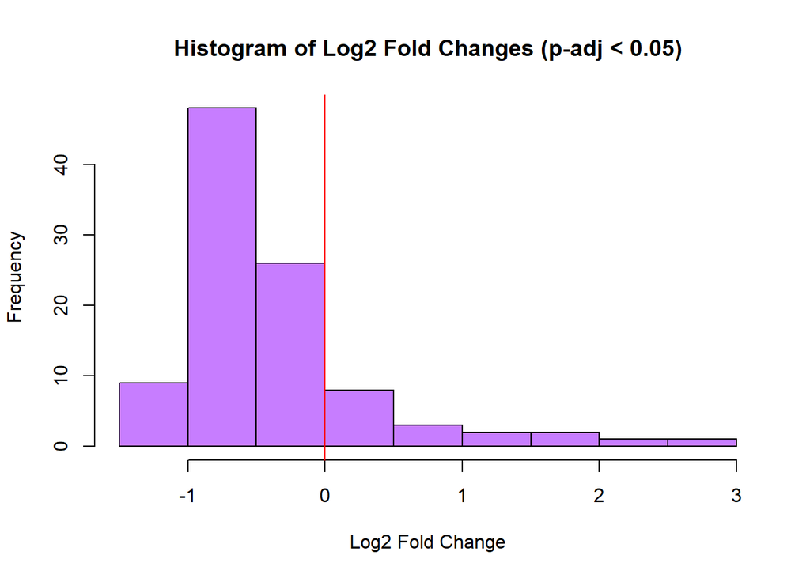

```r
hist(sig_005$log2FoldChange,
     main="Histogram of Log2 Fold Changes (p-adj < 0.05)",
     xlab="Log2 Fold Change",
     col = "#c77dff")
# Add a vertical line at zero on the x-axis
abline(v = 0, lty = 1, col = "red")#
```

```r
# dev.off()
```

```r
sig_counts_t <-data[sig_005$ensembl_gene_id, ] %>% t() %>%
  as.data.frame() %>%
  rownames_to_column(var = "Name")
sig_counts_t
```

| Name | ENSG00000040531 | ENSG00000066230 | ENSG00000077157 | ENSG00000092098 | ENSG00000099901 | ENSG00000100242 | ENSG00000102904 | ENSG00000103260 | ENSG00000104872 | ENSG00000104886 | ENSG00000104892 | ENSG00000104936 | ENSG00000104960 | ENSG00000106624 | ENSG00000108469 | ENSG00000108821 | ENSG00000111665 | ENSG00000112787 | ENSG00000114270 | ENSG00000116221 | ENSG00000116668 | ENSG00000117614 | ENSG00000126453 | ENSG00000126461 | ENSG00000133243 | ENSG00000135454 | ENSG00000137171 | ENSG00000141985 | ENSG00000142173 | … |
| --- | --- | --- | --- | --- | --- | --- | --- | --- | --- | --- | --- | --- | --- | --- | --- | --- | --- | --- | --- | --- | --- | --- | --- | --- | --- | --- | --- | --- | --- | --- |
| N_0026 | 499 | 653 | 150 | 294 | 209 | 1028 | 653 | 50 | 68 | 114 | 205 | 110 | 1799 | 41 | 335 | 83 | 369 | 83 | 38 | 50 | 33 | 3 | 1419 | 13 | 562 | 557 | 577 | 174 | 138 | … |
| N_0035 | 172 | 505 | 104 | 214 | 198 | 451 | 565 | 7 | 50 | 105 | 150 | 62 | 1602 | 19 | 129 | 70 | 293 | 4 | 11 | 100 | 24 | 8 | 442 | 32 | 674 | 749 | 440 | 68 | 197 | … |
| N_0036 | 461 | 575 | 182 | 390 | 257 | 584 | 685 | 28 | 57 | 156 | 215 | 118 | 1526 | 66 | 168 | 259 | 671 | 4 | 45 | 99 | 24 | 6 | 583 | 16 | 434 | 1277 | 673 | 71 | 228 | … |
| N_0039 | 150 | 519 | 36 | 207 | 305 | 716 | 606 | 22 | 61 | 160 | 115 | 36 | 1392 | 86 | 121 | 115 | 260 | 6 | 13 | 82 | 71 | 1 | 464 | 28 | 442 | 993 | 516 | 66 | 326 | … |
| N_0042 | 614 | 1359 | 90 | 529 | 349 | 937 | 745 | 38 | 82 | 278 | 218 | 198 | 2065 | 35 | 313 | 116 | 597 | 43 | 60 | 73 | 16 | 3 | 819 | 18 | 1158 | 1317 | 730 | 78 | 245 | … |
| N_0045 | 450 | 826 | 205 | 253 | 268 | 777 | 588 | 20 | 66 | 205 | 169 | 144 | 1619 | 51 | 230 | 178 | 586 | 41 | 32 | 99 | 11 | 3 | 713 | 22 | 591 | 776 | 634 | 161 | 212 | … |
| N_0046 | 515 | 533 | 24 | 227 | 285 | 777 | 429 | 18 | 81 | 314 | 158 | 67 | 1093 | 269 | 123 | 486 | 271 | 11 | 283 | 123 | 31 | 1 | 741 | 24 | 734 | 905 | 520 | 91 | 470 | … |
| N_0054 | 407 | 363 | 139 | 244 | 192 | 564 | 514 | 13 | 40 | 123 | 148 | 78 | 1069 | 119 | 150 | 226 | 536 | 1 | 42 | 116 | 30 | 8 | 670 | 20 | 477 | 757 | 492 | 89 | 195 | … |
| N_0055 | 366 | 481 | 18 | 213 | 214 | 950 | 467 | 25 | 58 | 134 | 61 | 63 | 1002 | 124 | 153 | 192 | 116 | 29 | 20 | 49 | 70 | 2 | 470 | 19 | 538 | 464 | 703 | 86 | 249 | … |
| N_0057 | 261 | 596 | 187 | 312 | 262 | 434 | 623 | 19 | 59 | 131 | 232 | 94 | 1214 | 18 | 123 | 119 | 284 | 10 | 65 | 138 | 7 | 6 | 438 | 8 | 384 | 982 | 599 | 77 | 142 | … |

[output cut: 28 more lines]

```r
sig_DEG_counts <- right_join(sample_data, sig_counts_t, by = "Name")
sig_DEG_counts
```

| ID | Group | Replicate | Name | ENSG00000040531 | ENSG00000066230 | ENSG00000077157 | ENSG00000092098 | ENSG00000099901 | ENSG00000100242 | ENSG00000102904 | ENSG00000103260 | ENSG00000104872 | ENSG00000104886 | ENSG00000104892 | ENSG00000104936 | ENSG00000104960 | ENSG00000106624 | ENSG00000108469 | ENSG00000108821 | ENSG00000111665 | ENSG00000112787 | ENSG00000114270 | ENSG00000116221 | ENSG00000116668 | ENSG00000117614 | ENSG00000126453 | ENSG00000126461 | ENSG00000133243 | ENSG00000135454 | … |
| --- | --- | --- | --- | --- | --- | --- | --- | --- | --- | --- | --- | --- | --- | --- | --- | --- | --- | --- | --- | --- | --- | --- | --- | --- | --- | --- | --- | --- | --- | --- |
| GSM3934989 | control | rep1 | N_0026 | 499 | 653 | 150 | 294 | 209 | 1028 | 653 | 50 | 68 | 114 | 205 | 110 | 1799 | 41 | 335 | 83 | 369 | 83 | 38 | 50 | 33 | 3 | 1419 | 13 | 562 | 557 | … |
| GSM3934990 | control | rep2 | N_0035 | 172 | 505 | 104 | 214 | 198 | 451 | 565 | 7 | 50 | 105 | 150 | 62 | 1602 | 19 | 129 | 70 | 293 | 4 | 11 | 100 | 24 | 8 | 442 | 32 | 674 | 749 | … |
| GSM3934991 | control | rep3 | N_0036 | 461 | 575 | 182 | 390 | 257 | 584 | 685 | 28 | 57 | 156 | 215 | 118 | 1526 | 66 | 168 | 259 | 671 | 4 | 45 | 99 | 24 | 6 | 583 | 16 | 434 | 1277 | … |
| GSM3934992 | control | rep4 | N_0039 | 150 | 519 | 36 | 207 | 305 | 716 | 606 | 22 | 61 | 160 | 115 | 36 | 1392 | 86 | 121 | 115 | 260 | 6 | 13 | 82 | 71 | 1 | 464 | 28 | 442 | 993 | … |
| GSM3934993 | control | rep5 | N_0042 | 614 | 1359 | 90 | 529 | 349 | 937 | 745 | 38 | 82 | 278 | 218 | 198 | 2065 | 35 | 313 | 116 | 597 | 43 | 60 | 73 | 16 | 3 | 819 | 18 | 1158 | 1317 | … |
| GSM3934994 | control | rep6 | N_0045 | 450 | 826 | 205 | 253 | 268 | 777 | 588 | 20 | 66 | 205 | 169 | 144 | 1619 | 51 | 230 | 178 | 586 | 41 | 32 | 99 | 11 | 3 | 713 | 22 | 591 | 776 | … |
| GSM3934995 | control | rep7 | N_0046 | 515 | 533 | 24 | 227 | 285 | 777 | 429 | 18 | 81 | 314 | 158 | 67 | 1093 | 269 | 123 | 486 | 271 | 11 | 283 | 123 | 31 | 1 | 741 | 24 | 734 | 905 | … |
| GSM3934996 | control | rep8 | N_0054 | 407 | 363 | 139 | 244 | 192 | 564 | 514 | 13 | 40 | 123 | 148 | 78 | 1069 | 119 | 150 | 226 | 536 | 1 | 42 | 116 | 30 | 8 | 670 | 20 | 477 | 757 | … |
| GSM3934997 | control | rep9 | N_0055 | 366 | 481 | 18 | 213 | 214 | 950 | 467 | 25 | 58 | 134 | 61 | 63 | 1002 | 124 | 153 | 192 | 116 | 29 | 20 | 49 | 70 | 2 | 470 | 19 | 538 | 464 | … |
| GSM3934998 | control | rep10 | N_0057 | 261 | 596 | 187 | 312 | 262 | 434 | 623 | 19 | 59 | 131 | 232 | 94 | 1214 | 18 | 123 | 119 | 284 | 10 | 65 | 138 | 7 | 6 | 438 | 8 | 384 | 982 | … |

[output cut: 28 more lines]

For Machine Learing we want to pick only the samples also evident in the methylation data:

```r
## load methylation sample data
sample_data_meth <- read.table(paste0(dir, "DATA/mbdseq/allMethylationSample_info.txt"),
           header = T, sep = ",")
sample_data_meth %>% view

## only 37 samples left with row 17 deleted
subset_sig_DEG_counts <- sig_DEG_counts[sig_DEG_counts$Name %in% sample_data_meth$Sample, ]
```

```r
## some files we found useful for later workflow

saveRDS(object = sig_005, file = paste0(dir, "ANALYSIS/DEGs/Output/sig_005.rds"))
write.csv(sig_005, paste0(dir, "ANALYSIS/DEGs/Output/sig_DEGs.csv"), row.names=FALSE)
write.csv(sig_DEG_counts, paste0(dir, "ANALYSIS/DEGs/Output/sig_DEG_counts.csv"), row.names=FALSE)
write.csv(subset_sig_DEG_counts, paste0(dir, "ANALYSIS/DEGs/Output/sig_DEG_counts_37samples.csv"), row.names=FALSE)
```

## Visualisation

[Example1](https://hbctraining.github.io/Training-modules/planning_successful_rnaseq/lessons/data_visualization.html) [Example2](https://angus.readthedocs.io/en/2019/diff-ex-and-viz.html) [Example3](https://hbctraining.github.io/Intro-to-R-with-DGE/lessons/B1_DGE_visualizing_results.html)

### VOLCANO PLOT

Also look into documentation: [EnhancedVolcano](https://bioconductor.org/packages/devel/bioc/vignettes/EnhancedVolcano/inst/doc/EnhancedVolcano.html)

Plot results:

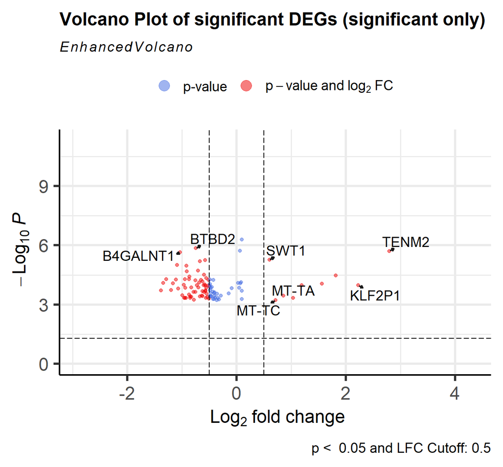

```r
alpha = 0.05
lfc_cutoff = 0.5

EnhancedVolcano(sig_005,
    lab = sig_005$external_gene_name,
    x = 'log2FoldChange',
    y = 'pvalue',
    FCcutoff = lfc_cutoff, # cut-off for absolute log2 fold-change
    title = "Volcano Plot of significant DEGs (significant only)",
    caption = paste("p < ", alpha, "and LFC Cutoff:", lfc_cutoff),
    pCutoff = alpha,
    drawConnectors = TRUE,
    widthConnectors = 0.75,
    pointSize = 1.5)
```

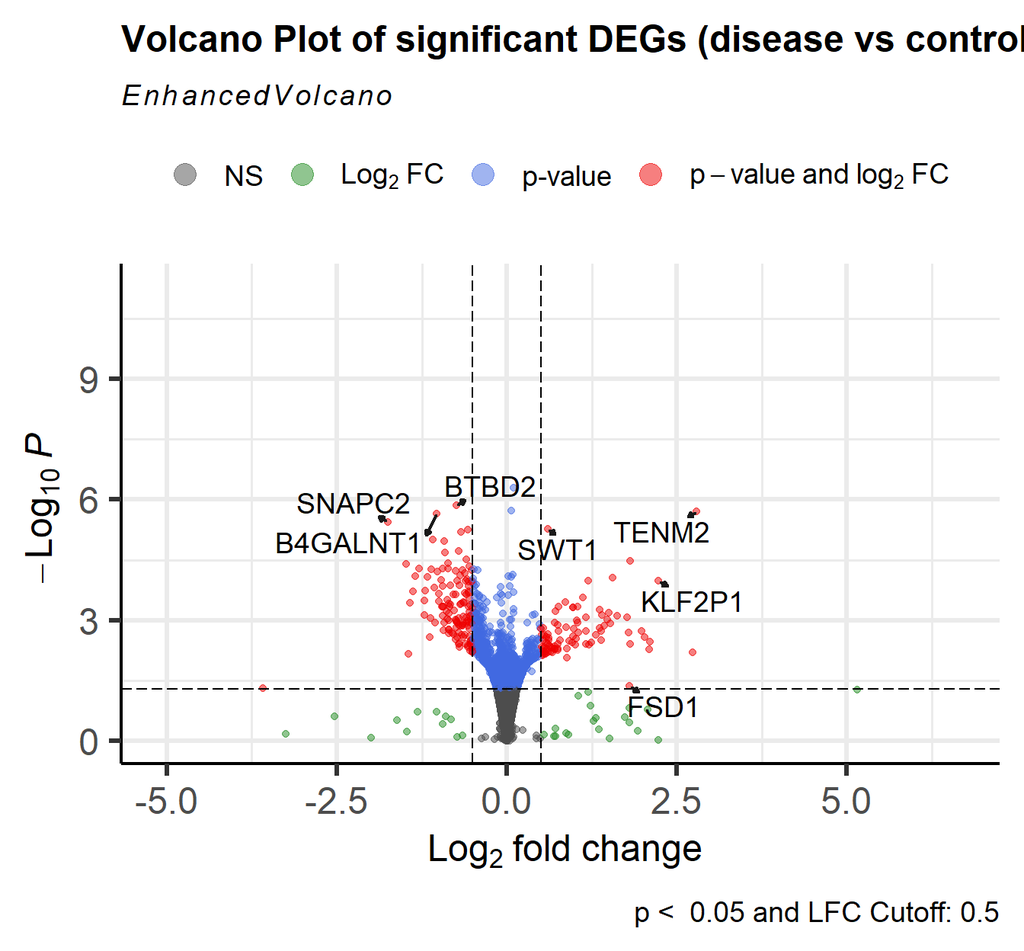

```r
EnhancedVolcano(resShrink,
    lab = resShrink$external_gene_name,
    x = 'log2FoldChange',
    y = 'pvalue',
    FCcutoff = lfc_cutoff, # cut-off for absolute log2 fold-change
    title = "Volcano Plot of significant DEGs (disease vs control)",
    caption = paste("p < ", alpha, "and LFC Cutoff:", lfc_cutoff),
    pCutoff = alpha,
    drawConnectors = TRUE,
    widthConnectors = 0.75,
    pointSize = 1.5)
```

### HEATMAP

Also plotted a Heatmap for top 30 genes, but excluded this plot from the presentation to make the slides be more uniform. Since we didn’t have time to recreate this for the methylation data.

Plot top 30 genes (based on LFC):

```r
top <-sig_005[order(abs(sig_005$log2FoldChange),
                             decreasing = TRUE), ][1:30, ]


vsd_top <- assay(vsd)[top$ensembl_gene_id,]
vsd_top %>% head
```

```
##                   N_0026   N_0035   N_0036   N_0039   N_0042   N_0045   N_0046
## ENSG00000145934 3.156395 1.009489 2.815898 2.061506 1.873619 2.740966 1.009489
## ENSG00000231240 1.952237 1.009489 2.815898 1.009489 2.214563 4.209455 1.009489
## ENSG00000250039 2.320960 2.510129 3.001582 1.009489 3.569277 3.757215 2.853792
## ENSG00000282121 4.977706 2.811854 3.001582 3.198292 3.898830 4.907454 3.911381
## ENSG00000112787 6.283589 3.053413 2.815898 3.371191 5.166335 5.224376 3.816355
## ENSG00000197191 4.244459 6.067874 5.440666 4.774662 4.791385 4.209455 3.042380
##                   N_0054   N_0055   N_0057   N_0058   N_0060    W_001    W_002
## ENSG00000145934 1.982758 1.009489 3.229390 2.054524 9.649687 2.100352 2.847334
## ENSG00000231240 3.052303 3.495800 2.078512 1.009489 3.232772 1.009489 3.476272
## ENSG00000250039 1.982758 2.740485 3.403928 2.987055 7.103524 2.100352 2.847334
## ENSG00000282121 3.217171 5.056225 2.490279 3.771851 7.884034 3.985459 4.299228
## ENSG00000112787 1.982758 5.147900 3.938375 3.886121 5.380751 3.269108 4.715506
## ENSG00000197191 3.726313 4.481258 5.086883 4.181608 5.163634 2.100352 2.625170
##                    W_004    W_006    W_007    W_008    W_010    W_011    W_012
## ENSG00000145934 1.978770 2.019916 1.009489 1.009489 1.009489 1.009489 3.020093
## ENSG00000231240 3.044822 6.653497 2.810979 1.009489 2.716214 3.826999 2.612314
## ENSG00000250039 4.166085 2.697621 3.726492 3.532840 3.143635 2.361133 3.577818
## ENSG00000282121 4.505680 3.913761 5.392200 4.452450 4.512208 4.573393 4.133542
## ENSG00000112787 2.633047 2.019916 3.255489 2.473294 2.716214 2.361133 3.458700
## ENSG00000197191 3.717276 3.697211 3.052451 1.009489 1.009489 3.051003 2.833086
##                    W_015    W_017    W_018    W_023    W_028     W_030    W_033
## ENSG00000145934 3.474273 2.937817 3.734365 2.574178 2.523777 11.294990 1.009489
## ENSG00000231240 4.801841 1.009489 3.058973 2.141645 4.323279  6.254149 1.009489
## ENSG00000250039 3.231252 2.706964 3.901154 3.343526 3.336734  7.152762 1.009489
## ENSG00000282121 4.159929 3.710182 4.622619 4.906220 4.436528  7.999322 3.901477
## ENSG00000112787 4.568498 2.419965 5.346200 5.513788 2.263584  2.611365 3.786860
## ENSG00000197191 3.231252 2.706964 3.198094 4.073223 3.336734  3.576480 3.901477
##                     W_035    W_037    W_039    W_040    W_047    W_049    W_052
## ENSG00000145934 11.570325 9.917088 2.361673 4.561903 3.099522 2.179253 1.009489
## ENSG00000231240  4.441502 4.024161 3.494958 4.452016 2.396024 6.374077 6.459395
## ENSG00000250039  8.658449 6.124417 2.638867 5.470003 3.267049 2.943446 2.795644
## ENSG00000282121  9.276955 8.140511 3.363016 5.226204 3.671330 3.900744 4.492939
## ENSG00000112787  2.526664 4.232840 3.216594 3.266102 3.549513 2.794145 1.009489
## ENSG00000197191  4.328177 3.778780 4.175189 2.299111 3.415695 2.794145 3.237441
##                    W_053    W_054    W_058
## ENSG00000145934 1.009489 4.065087 2.872745
## ENSG00000231240 1.009489 2.968383 2.872745
## ENSG00000250039 4.631061 3.165465 2.648114
## ENSG00000282121 3.762430 5.046601 3.738945
## ENSG00000112787 3.621735 4.670012 3.062768
## ENSG00000197191 2.110428 3.336606 2.369577
```

```r
set.seed(1)

## are sample names and order of sample names in vsd the same
all(sample_data$Name == colnames(vsd_top)) # YES, we can add group column to plot
```

```
## [1] TRUE
```

```r
## check if ensembl ids match gene symbols
all(rownames(vsd_top) == top$ensembl_gene_id) # should return TRUE
```

```
## [1] TRUE
```

Out of 30 top genes only 25 have gene symbols:

```r
# filter out entries in top that don't have matching gene symbols
filtered_top <- top[!is.na(top$external_gene_name) & nchar(top$external_gene_name) > 0, ]


# subset vsd_top based on the filtered top data

vsd_top_filtered <- assay(vsd)[filtered_top$ensembl_gene_id, ]

# check if row names in vsd_top_filtered match Ensembl IDs in filtered_top
all(rownames(vsd_top_filtered) == filtered_top$ensembl_gene_id) # should return TRUE
```

```
## [1] TRUE
```

```r
all(colnames(vsd_top_filtered) == sample_data$Name) # should return TRUE
```

```
## [1] TRUE
```

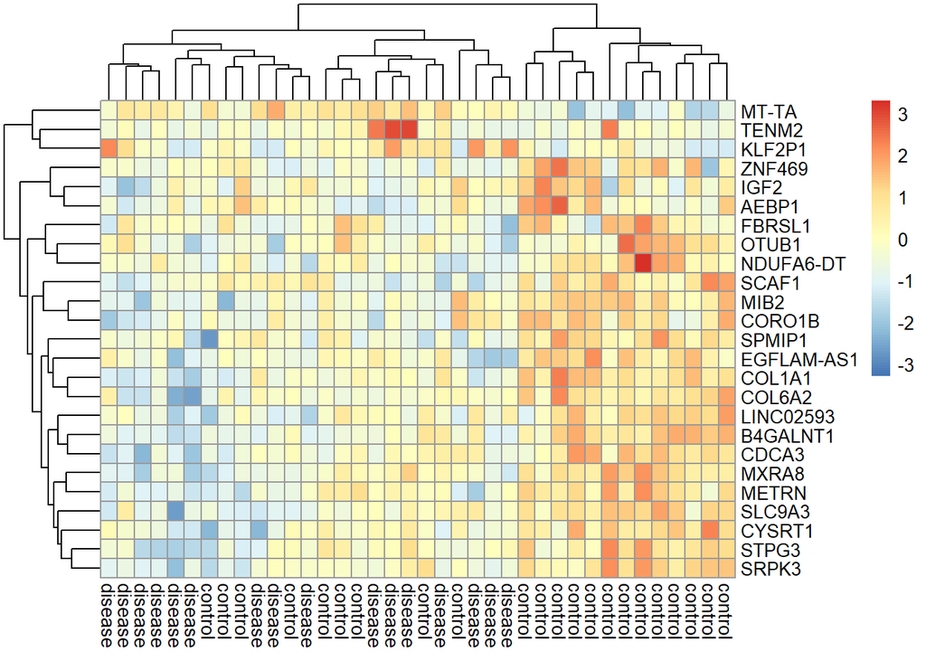

```r
# generate the heatmap with gene symbols as row labels
pheatmap(vsd_top_filtered, scale="row",
         labels_row = filtered_top$external_gene_name,
         labels_col = sample_data$Group,
         cluster_rows = TRUE)
```

```r
### order by samples if needed?
```

### Boxplot

Boxplot of control vs disease (count distribution across samples):

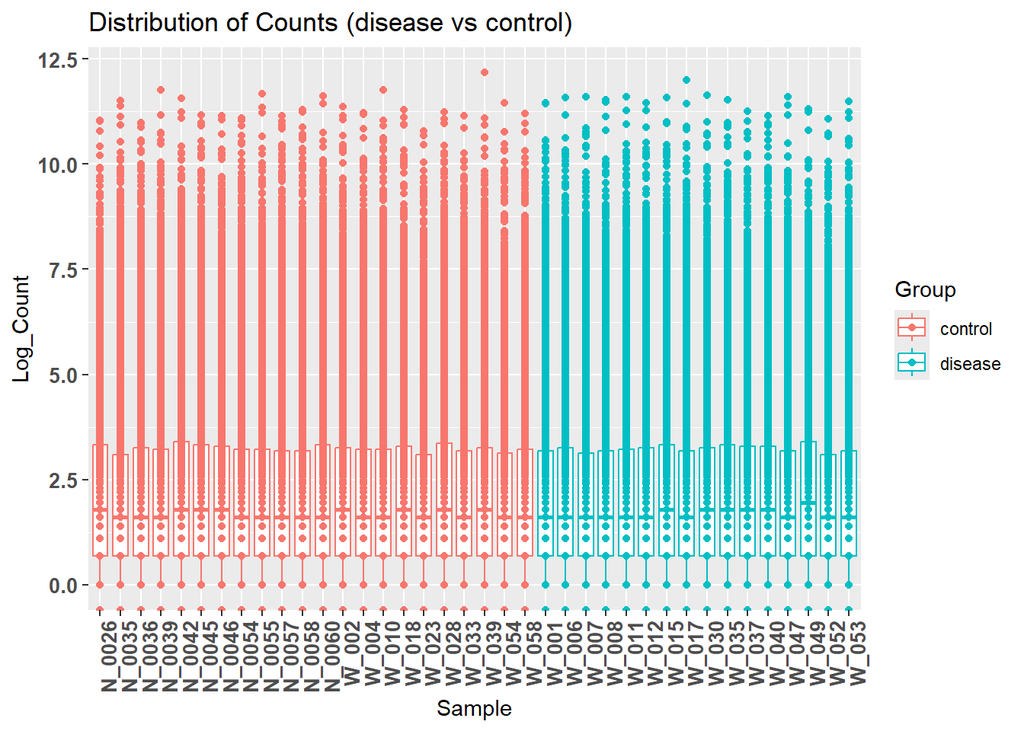

```r
counts <-counts(dds) %>%
  as.data.frame() %>%
  rownames_to_column(var = "ENSEMBL_ID")

counts_melt <- reshape2::melt(counts,
                  variable.name = "Name",
                  value.name = "Count")

counts_merge <- merge(counts_melt,
                          sample_data, by = "Name") %>% arrange(Group)

counts_merge <- counts_merge %>%
  mutate(Name = factor(Name, levels = unique(Name[order(Group)])))


boxplot_rep_all <- ggplot(counts_merge,
                     aes(x = reorder(Name, Group),
                         y = log(Count),
                         color = Group)) +
  geom_boxplot() +
  geom_point(aes(color  = Group))+
  labs(title = "Distribution of Counts (disease vs control)",
       x = "Sample",
       y = "Log_Count") +
  theme_gray()+
  theme(axis.text.x = element_text(face = "bold",
                                   size = 10, angle = 90, hjust = 1)) +
  theme(axis.text.y = element_text(face = "bold", size =10))


boxplot_rep_all
```

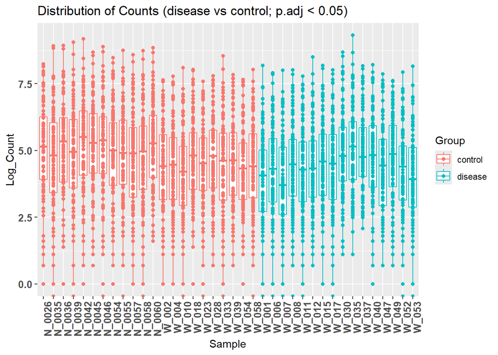

```r
sig_counts <- counts(dds)[sig_005$ensembl_gene_id, ] %>%
   as.data.frame() %>%
   rownames_to_column(var = "ENSEMBL_ID")

sig_counts_melt <- reshape2::melt(sig_counts,
                   variable.name = "Name",
                   value.name = "Count")


sig_counts_merge <- merge(sig_counts_melt,
                           sample_data, by = "Name") %>% arrange(Group)



sig_counts_merge <- sig_counts_merge %>%
  mutate(Name = factor(Name, levels = unique(Name[order(Group)])))


boxplot_rep_sig <- ggplot(sig_counts_merge,
                     aes(x = reorder(Name, Group),
                         y = log(Count),
                         color = Group)) +
  geom_boxplot() +
  geom_point(aes(color  = Group))+
  labs(title = "Distribution of Counts (disease vs control; p.adj < 0.05)",
       x = "Sample",
       y = "Log_Count") +
  theme_gray()+
  theme(axis.text.x = element_text(face = "bold",
                                   size = 10, angle = 90, hjust = 1)) +
  theme(axis.text.y = element_text(face = "bold", size =10))


boxplot_rep_sig
```

```r
top10 <- sig_005[order(abs(sig_005$log2FoldChange), decreasing = TRUE), ][1:10, ]
# top10 <-subset(sig_counts_merge, ENSEMBL_ID %in% top10$ensembl_gene_id)


top10_counts <- sig_counts_merge %>%
  dplyr::filter(ENSEMBL_ID %in% top10$ensembl_gene_id)
top10
```

|  | ensembl_gene_id | baseMean | log2FoldChange | lfcSE | pvalue | padj | external_gene_name | description | gene_exp |
| --- | --- | --- | --- | --- | --- | --- | --- | --- | --- |
| 30 | ENSG00000145934 | 28.25064 | 2.794825 | 1.0308087 | 1.974783e-06 | 0.003773406 | TENM2 | teneurin transmembrane protein 2 [Source:HGNC Symbol;Acc:HGNC:29943] | up |
| 61 | ENSG00000231240 | 13.59615 | 2.227563 | 0.7367840 | 1.044159e-04 | 0.021130706 | KLF2P1 | Kruppel like factor 2 pseudogene 1 [Source:HGNC Symbol;Acc:HGNC:49280] | up |
| 72 | ENSG00000250039 | 11.42257 | 1.814448 | 0.5037176 | 3.379092e-05 | 0.018722336 |  | novel transcript | up |
| 100 | ENSG00000282121 | 28.75934 | 1.561787 | 0.4545127 | 8.795926e-05 | 0.021130706 |  | novel transcript, antisense to ANK3 | up |
| 18 | ENSG00000112787 | 13.18745 | -1.380134 | 0.5097642 | 1.930102e-04 | 0.028274834 | FBRSL1 | fibrosin like 1 [Source:HGNC Symbol;Acc:HGNC:29308] | down |
| 47 | ENSG00000197191 | 11.74707 | -1.342163 | 0.4428327 | 7.918440e-05 | 0.021130706 | CYSRT1 | cysteine rich tail 1 [Source:HGNC Symbol;Acc:HGNC:30529] | down |
| 16 | ENSG00000108821 | 82.17204 | -1.289095 | 0.4119292 | 5.276335e-05 | 0.018722336 | COL1A1 | collagen type I alpha 1 chain [Source:HGNC Symbol;Acc:HGNC:2197] | down |
| 37 | ENSG00000167244 | 286.97340 | -1.199301 | 0.4425447 | 1.835216e-04 | 0.027655289 | IGF2 | insulin like growth factor 2 [Source:HGNC Symbol;Acc:HGNC:5466] | down |
| 59 | ENSG00000228113 | 486.77896 | 1.192776 | 0.6274996 | 1.053207e-04 | 0.021130706 |  | novel transcript, antisense to STEAP4 | up |
| 55 | ENSG00000223764 | 103.25311 | -1.162699 | 0.3890530 | 8.462577e-05 | 0.021130706 | LINC02593 | long intergenic non-protein coding RNA 2593 [Source:HGNC Symbol;Acc:HGNC:53933] | down |

```r
top10ids<-top10_counts$ENSEMBL_ID %>% unique()


top10_annot<-sig_005 %>% dplyr::select(ensembl_gene_id, external_gene_name) %>%
  dplyr::filter(ensembl_gene_id %in% top10ids)
top10_annot
```

| ensembl_gene_id | external_gene_name |
| --- | --- |
| ENSG00000108821 | COL1A1 |
| ENSG00000112787 | FBRSL1 |
| ENSG00000145934 | TENM2 |
| ENSG00000167244 | IGF2 |
| ENSG00000197191 | CYSRT1 |
| ENSG00000223764 | LINC02593 |
| ENSG00000228113 |  |
| ENSG00000231240 | KLF2P1 |
| ENSG00000250039 |  |
| ENSG00000282121 |  |

### Boxplot top 10 Genes

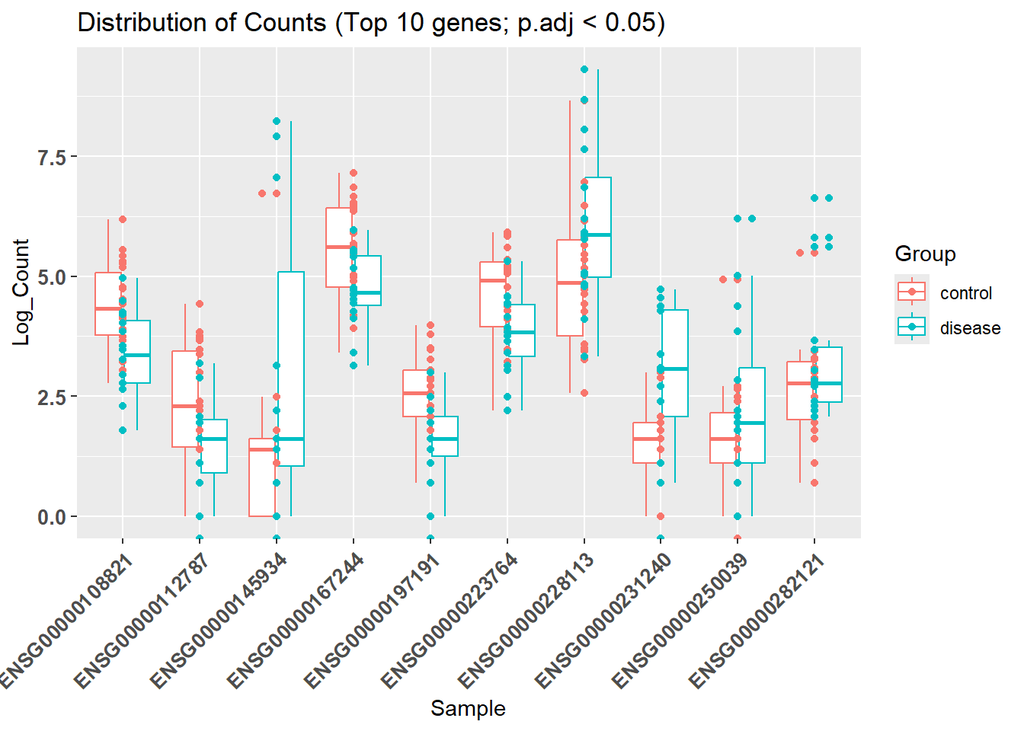

```r
boxplot_top_gene <- ggplot(top10_counts,
                     aes(x = reorder(ENSEMBL_ID, Group),
                         y = log(Count),
                         color = Group)) +
  geom_boxplot() +
  geom_point(aes(color  = Group))+
  labs(title = "Distribution of Counts (Top 10 genes; p.adj < 0.05)",
       x = "Sample",
       y = "Log_Count") +
  theme_gray()+
  theme(axis.text.x = element_text(face = "bold",
                                   size = 10, angle = 45, hjust = 1)) +
  theme(axis.text.y = element_text(face = "bold", size =10))
  # geom_text(aes(label = top10_annot$external_gene_name),
  #           hjust = -0.3, vjust = 0.5, size = 4)


boxplot_top_gene
```

```r
## save workspace
save.image(paste0(dir, "ANALYSIS/DEGs/rnaseq.RData"))
```